# DATA 621 Blog 2: Timing Operations in R

Ilya Kats

### Introduction

R has many ways of accomplishing the same thing - base functions, various packages. Sometimes the data set is small and there is plenty of time. Other times, there is a lot of data and computational time makes a difference. Below are some ways of timing operations in R, so that you can compare various approaches to find the most optimal.

### Data Set

First let us generate a random data set. Since this is just about timing any data set will do. The code below creates 1,000,000 random observations - large enough to take a bit of time if you manipulate it.

```r
x <- runif(1000000, 0, 100)
y <- rnorm(1000000, 0, 10)
```

### `tictoc` Package

At the most basic level you can simply save the system time to a variable before your code’s execution and right after. The difference will tell you how long the code rang (with a bit added because of the wrapper code). This can be easily accomplished with `Sys.time()` call. The package `tictoc` does a very similar thing with a bit more functionality.

```r
library(tictoc)
```

To start timing you use `tic()` and to stop it you put `toc()`. You can add a name to the timer and save results in a log (the default is not to save it: `log = FALSE`).

```r
tic("Linear regression")
l1 <- lm(y ~ x)
toc(log = TRUE)
```

```
## Linear regression: 1.7 sec elapsed
```

One big benefit of this method is that you can have nested timers.

```r
tic("Linear regression - outer")
tic("Linear regression - inner")
l1 <- lm(y ~ x)
toc(log = TRUE)
```

```
## Linear regression - inner: 1.36 sec elapsed
```

```r
l2 <- lm(y ~ x)
toc(log = TRUE)
```

```
## Linear regression - outer: 2.5 sec elapsed
```

Finally, you can view results of the log.

```r
tic.log(format = TRUE)
```

```
## [[1]]
## [1] "Linear regression: 1.7 sec elapsed"
##
## [[2]]
## [1] "Linear regression - inner: 1.36 sec elapsed"
##
## [[3]]
## [1] "Linear regression - outer: 2.5 sec elapsed"
```

### `microbenchmark` Package

If you would like more interpretative capabilities, then `microbenchmark` package may help. The syntax is slightly different. You pass your code as an argument to the `microbenchmark` function.

```r
library(microbenchmark)

( mb <- microbenchmark(lm(y ~ x), times=10) )
```

```
## Unit: milliseconds
##       expr      min       lq     mean  median       uq      max neval
##  lm(y ~ x) 929.6852 960.9372 1049.082 1038.96 1148.547 1200.407    10
```

This package is similar to the base function `system.time()`. However, base function runs only once. One great feature of `microbenchmark` is that you can evaluate the expression multiple times and get back a few statistical values - mean, median, min, max. The code above runs 10 times. Another great feature is its integration with `ggplot2`.

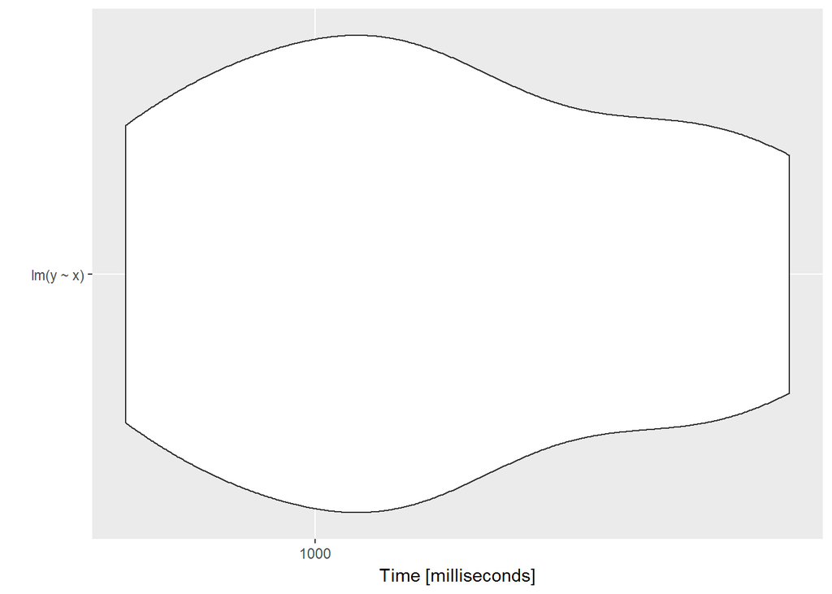

```r
library(ggplot2)
autoplot(mb)
```

### References

- Hadley Wickham, Advanced R: Performance, http://adv-r.had.co.nz/Performance.html
- Alexej’s Blog, 5 ways to measure running time of R code, https://www.r-bloggers.com/5-ways-to-measure-running-time-of-r-code/